# Optimal Treatment Analysis

## Outcome Variable

**Outcome Variable:** haz

## Predictor Variables

**Intervention Variable:** gagebrth

**Adjustment Set:**

- arm
- sex
- W_mage
- meducyrs
- feducyrs
- hhwealth_quart
- W_nrooms
- brthmon
- W_parity
- impsan
- delta_W_mage
- delta_meducyrs
- delta_feducyrs
- delta_hhwealth_quart
- delta_W_nrooms
- delta_brthmon
- delta_W_parity
- delta_impsan

## Stratifying Variables

The analysis was stratified on these variable(s):

- agecat
- studyid
- country

## Data Summary

| agecat | studyid | country | gagebrth | n_cell | n |
| --- | --- | --- | --- | --- | --- |
| Birth | CMC-V-BCS-2002 | INDIA | Full or late term | 58 | 92 |
| Birth | CMC-V-BCS-2002 | INDIA | Preterm | 11 | 92 |
| Birth | CMC-V-BCS-2002 | INDIA | Early term | 23 | 92 |
| Birth | COHORTS | GUATEMALA | Full or late term | 341 | 617 |
| Birth | COHORTS | GUATEMALA | Preterm | 95 | 617 |
| Birth | COHORTS | GUATEMALA | Early term | 181 | 617 |
| Birth | COHORTS | INDIA | Full or late term | 570 | 1293 |
| Birth | COHORTS | INDIA | Preterm | 285 | 1293 |
| Birth | COHORTS | INDIA | Early term | 438 | 1293 |
| Birth | COHORTS | PHILIPPINES | Full or late term | 1164 | 3024 |
| Birth | COHORTS | PHILIPPINES | Preterm | 649 | 3024 |
| Birth | COHORTS | PHILIPPINES | Early term | 1211 | 3024 |
| Birth | IRC | INDIA | Full or late term | 238 | 369 |
| Birth | IRC | INDIA | Preterm | 36 | 369 |
| Birth | IRC | INDIA | Early term | 95 | 369 |
| Birth | JiVitA-3 | BANGLADESH | Full or late term | 10944 | 21442 |
| Birth | JiVitA-3 | BANGLADESH | Preterm | 4514 | 21442 |
| Birth | JiVitA-3 | BANGLADESH | Early term | 5984 | 21442 |
| Birth | Keneba | GAMBIA | Full or late term | 734 | 1515 |
| Birth | Keneba | GAMBIA | Preterm | 235 | 1515 |
| Birth | Keneba | GAMBIA | Early term | 546 | 1515 |
| Birth | NIH-Crypto | BANGLADESH | Full or late term | 162 | 732 |
| Birth | NIH-Crypto | BANGLADESH | Preterm | 257 | 732 |
| Birth | NIH-Crypto | BANGLADESH | Early term | 313 | 732 |
| Birth | PROBIT | BELARUS | Full or late term | 7100 | 13893 |
| Birth | PROBIT | BELARUS | Preterm | 472 | 13893 |
| Birth | PROBIT | BELARUS | Early term | 6321 | 13893 |
| 6 months | CMC-V-BCS-2002 | INDIA | Full or late term | 212 | 347 |
| 6 months | CMC-V-BCS-2002 | INDIA | Preterm | 52 | 347 |
| 6 months | CMC-V-BCS-2002 | INDIA | Early term | 83 | 347 |

[output cut: 57 more lines]

The following strata were considered:

- agecat: 24 months, studyid: CMC-V-BCS-2002, country: INDIA
- agecat: 24 months, studyid: COHORTS, country: GUATEMALA
- agecat: 24 months, studyid: COHORTS, country: INDIA
- agecat: 24 months, studyid: COHORTS, country: PHILIPPINES
- agecat: 24 months, studyid: IRC, country: INDIA
- agecat: 24 months, studyid: JiVitA-3, country: BANGLADESH
- agecat: 24 months, studyid: Keneba, country: GAMBIA
- agecat: 24 months, studyid: NIH-Crypto, country: BANGLADESH
- agecat: 24 months, studyid: PROBIT, country: BELARUS
- agecat: 24 months, studyid: TanzaniaChild2, country: TANZANIA, UNITED REPUBLIC OF
- agecat: 6 months, studyid: CMC-V-BCS-2002, country: INDIA
- agecat: 6 months, studyid: COHORTS, country: GUATEMALA
- agecat: 6 months, studyid: COHORTS, country: INDIA
- agecat: 6 months, studyid: COHORTS, country: PHILIPPINES
- agecat: 6 months, studyid: IRC, country: INDIA
- agecat: 6 months, studyid: JiVitA-3, country: BANGLADESH
- agecat: 6 months, studyid: Keneba, country: GAMBIA
- agecat: 6 months, studyid: NIH-Crypto, country: BANGLADESH
- agecat: 6 months, studyid: PROBIT, country: BELARUS
- agecat: 6 months, studyid: TanzaniaChild2, country: TANZANIA, UNITED REPUBLIC OF
- agecat: Birth, studyid: CMC-V-BCS-2002, country: INDIA
- agecat: Birth, studyid: COHORTS, country: GUATEMALA
- agecat: Birth, studyid: COHORTS, country: INDIA
- agecat: Birth, studyid: COHORTS, country: PHILIPPINES
- agecat: Birth, studyid: IRC, country: INDIA
- agecat: Birth, studyid: JiVitA-3, country: BANGLADESH
- agecat: Birth, studyid: Keneba, country: GAMBIA
- agecat: Birth, studyid: NIH-Crypto, country: BANGLADESH
- agecat: Birth, studyid: PROBIT, country: BELARUS

### Dropped Strata

Some strata were dropped due to rare outcomes:

- agecat: 24 months, studyid: TanzaniaChild2, country: TANZANIA, UNITED REPUBLIC OF

## Methods Detail

We’re interested in the causal parameters $E[Y_a]$ for all values of $a \in \mathcal{A}$. These parameters represent the mean outcome if, possibly contrary to fact, we intervened to set all units to have $A=a$. Under the randomization and positivity assumptions, these are identified by the statistical parameters $\psi_a=E_W[E_{Y|A,W}(Y|A=a,W)]$. In addition, we’re interested in the mean of $Y$, $E[Y]$ under no intervention (the observed mean). We will estimate these parameters by using SuperLearner to fit the relevant likelihood factors – $E_{Y|A,W}(Y|A=a,W)$ and $p(A=a|W)$, and then updating our likelihood fit using a joint TMLE.

For unadjusted analyses ($W=\{\}$), initial likelihoods were estimated using Lrnr_glm to estimate the simple $E(Y|A)$ and Lrnr_mean to estimate $p(A)$. For adjusted analyses, a small library containing Lrnr_glmnet, Lrnr_xgboost, and Lrnr_mean was used.

# Results Detail

## Results Plots

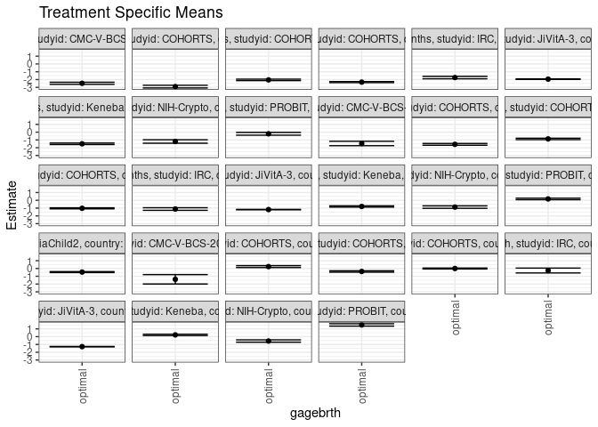

## Results Table

### Parameter: TSM

| agecat | studyid | country | intervention_level | baseline_level | estimate | ci_lower | ci_upper |
| --- | --- | --- | --- | --- | --- | --- | --- |
| Birth | CMC-V-BCS-2002 | INDIA | optimal | observed | -1.3890422 | -1.9945320 | -0.7835524 |
| Birth | COHORTS | GUATEMALA | optimal | observed | 0.2413036 | 0.1172019 | 0.3654053 |
| Birth | COHORTS | INDIA | optimal | observed | -0.3830486 | -0.4718892 | -0.2942080 |
| Birth | COHORTS | PHILIPPINES | optimal | observed | -0.0029289 | -0.0611504 | 0.0552926 |
| Birth | IRC | INDIA | optimal | observed | -0.2614355 | -0.5737464 | 0.0508753 |
| Birth | JiVitA-3 | BANGLADESH | optimal | observed | -1.2823158 | -1.3058344 | -1.2587971 |
| Birth | Keneba | GAMBIA | optimal | observed | 0.2259583 | 0.1391619 | 0.3127547 |
| Birth | NIH-Crypto | BANGLADESH | optimal | observed | -0.5621398 | -0.7115604 | -0.4127192 |
| Birth | PROBIT | BELARUS | optimal | observed | 1.5065999 | 1.3523278 | 1.6608720 |
| 6 months | CMC-V-BCS-2002 | INDIA | optimal | observed | -1.4576589 | -1.7390286 | -1.1762892 |
| 6 months | COHORTS | GUATEMALA | optimal | observed | -1.5665996 | -1.6829880 | -1.4502112 |
| 6 months | COHORTS | INDIA | optimal | observed | -0.8711421 | -0.9618540 | -0.7804303 |
| 6 months | COHORTS | PHILIPPINES | optimal | observed | -1.0251327 | -1.0905410 | -0.9597245 |
| 6 months | IRC | INDIA | optimal | observed | -1.1192850 | -1.2882428 | -0.9503272 |
| 6 months | JiVitA-3 | BANGLADESH | optimal | observed | -1.1902883 | -1.2181136 | -1.1624629 |
| 6 months | Keneba | GAMBIA | optimal | observed | -0.7891336 | -0.8729478 | -0.7053195 |
| 6 months | NIH-Crypto | BANGLADESH | optimal | observed | -0.8697974 | -1.0288687 | -0.7107261 |
| 6 months | PROBIT | BELARUS | optimal | observed | 0.1783565 | 0.0806796 | 0.2760334 |
| 6 months | TanzaniaChild2 | TANZANIA, UNITED REPUBLIC OF | optimal | observed | -0.4617332 | -0.5258975 | -0.3975688 |
| 24 months | CMC-V-BCS-2002 | INDIA | optimal | observed | -2.4832802 | -2.6179178 | -2.3486425 |
| 24 months | COHORTS | GUATEMALA | optimal | observed | -2.9062793 | -3.0789649 | -2.7335937 |
| 24 months | COHORTS | INDIA | optimal | observed | -2.0431557 | -2.1387314 | -1.9475799 |
| 24 months | COHORTS | PHILIPPINES | optimal | observed | -2.3307857 | -2.4002207 | -2.2613506 |
| 24 months | IRC | INDIA | optimal | observed | -1.7442822 | -1.9022197 | -1.5863447 |
| 24 months | JiVitA-3 | BANGLADESH | optimal | observed | -1.9488850 | -1.9863618 | -1.9114081 |
| 24 months | Keneba | GAMBIA | optimal | observed | -1.4955000 | -1.5912224 | -1.3997776 |
| 24 months | NIH-Crypto | BANGLADESH | optimal | observed | -1.1994950 | -1.4238589 | -0.9751311 |
| 24 months | PROBIT | BELARUS | optimal | observed | -0.2099818 | -0.3914684 | -0.0284952 |

### Parameter: E(Y)

| agecat | studyid | country | intervention_level | baseline_level | estimate | ci_lower | ci_upper |
| --- | --- | --- | --- | --- | --- | --- | --- |
| Birth | CMC-V-BCS-2002 | INDIA | observed | observed | -0.9611957 | -1.1776967 | -0.7446946 |
| Birth | COHORTS | GUATEMALA | observed | observed | 0.0530794 | -0.0441925 | 0.1503513 |
| Birth | COHORTS | INDIA | observed | observed | -0.6072158 | -0.6675691 | -0.5468624 |
| Birth | COHORTS | PHILIPPINES | observed | observed | -0.2492460 | -0.2884729 | -0.2100192 |
| Birth | IRC | INDIA | observed | observed | -0.3102981 | -0.4751168 | -0.1454794 |
| Birth | JiVitA-3 | BANGLADESH | observed | observed | -1.5980879 | -1.6176172 | -1.5785586 |
| Birth | Keneba | GAMBIA | observed | observed | 0.0278680 | -0.0365315 | 0.0922674 |
| Birth | NIH-Crypto | BANGLADESH | observed | observed | -0.9094945 | -0.9809370 | -0.8380521 |
| Birth | PROBIT | BELARUS | observed | observed | 1.3114417 | 1.1524752 | 1.4704082 |
| 6 months | CMC-V-BCS-2002 | INDIA | observed | observed | -1.3856004 | -1.5319935 | -1.2392073 |
| 6 months | COHORTS | GUATEMALA | observed | observed | -1.8315428 | -1.9081267 | -1.7549589 |
| 6 months | COHORTS | INDIA | observed | observed | -0.9630335 | -1.0220763 | -0.9039908 |
| 6 months | COHORTS | PHILIPPINES | observed | observed | -1.1409862 | -1.1830414 | -1.0989310 |
| 6 months | IRC | INDIA | observed | observed | -1.2321263 | -1.3660720 | -1.0981806 |
| 6 months | JiVitA-3 | BANGLADESH | observed | observed | -1.3168751 | -1.3402193 | -1.2935309 |
| 6 months | Keneba | GAMBIA | observed | observed | -0.8948084 | -0.9510697 | -0.8385471 |
| 6 months | NIH-Crypto | BANGLADESH | observed | observed | -1.1986783 | -1.2700937 | -1.1272630 |
| 6 months | PROBIT | BELARUS | observed | observed | 0.0980074 | 0.0062724 | 0.1897424 |
| 6 months | TanzaniaChild2 | TANZANIA, UNITED REPUBLIC OF | observed | observed | -0.5419570 | -0.5926042 | -0.4913098 |
| 24 months | CMC-V-BCS-2002 | INDIA | observed | observed | -2.5319389 | -2.6335015 | -2.4303762 |
| 24 months | COHORTS | GUATEMALA | observed | observed | -2.9911195 | -3.0733804 | -2.9088586 |
| 24 months | COHORTS | INDIA | observed | observed | -2.1289450 | -2.1901830 | -2.0677069 |
| 24 months | COHORTS | PHILIPPINES | observed | observed | -2.4144884 | -2.4596605 | -2.3693164 |
| 24 months | IRC | INDIA | observed | observed | -1.7964915 | -1.8912047 | -1.7017782 |
| 24 months | JiVitA-3 | BANGLADESH | observed | observed | -2.0156596 | -2.0439781 | -1.9873411 |
| 24 months | Keneba | GAMBIA | observed | observed | -1.5800865 | -1.6398819 | -1.5202911 |
| 24 months | NIH-Crypto | BANGLADESH | observed | observed | -1.4412646 | -1.5249156 | -1.3576135 |
| 24 months | PROBIT | BELARUS | observed | observed | -0.1442891 | -0.4253755 | 0.1367972 |

### Parameter: PAR

| agecat | studyid | country | intervention_level | baseline_level | estimate | ci_lower | ci_upper |
| --- | --- | --- | --- | --- | --- | --- | --- |
| Birth | CMC-V-BCS-2002 | INDIA | optimal | observed | 0.4278465 | -0.1312502 | 0.9869433 |
| Birth | COHORTS | GUATEMALA | optimal | observed | -0.1882242 | -0.2775666 | -0.0988818 |
| Birth | COHORTS | INDIA | optimal | observed | -0.2241671 | -0.2926686 | -0.1556657 |
| Birth | COHORTS | PHILIPPINES | optimal | observed | -0.2463171 | -0.2942343 | -0.1983999 |
| Birth | IRC | INDIA | optimal | observed | -0.0488626 | -0.3116683 | 0.2139432 |
| Birth | JiVitA-3 | BANGLADESH | optimal | observed | -0.3157721 | -0.3332652 | -0.2982790 |
| Birth | Keneba | GAMBIA | optimal | observed | -0.1980903 | -0.2665903 | -0.1295903 |
| Birth | NIH-Crypto | BANGLADESH | optimal | observed | -0.3473547 | -0.4806777 | -0.2140318 |
| Birth | PROBIT | BELARUS | optimal | observed | -0.1951581 | -0.2513994 | -0.1389169 |
| 6 months | CMC-V-BCS-2002 | INDIA | optimal | observed | 0.0720585 | -0.1775334 | 0.3216504 |
| 6 months | COHORTS | GUATEMALA | optimal | observed | -0.2649432 | -0.3589340 | -0.1709523 |
| 6 months | COHORTS | INDIA | optimal | observed | -0.0918914 | -0.1590233 | -0.0247595 |
| 6 months | COHORTS | PHILIPPINES | optimal | observed | -0.1158535 | -0.1676001 | -0.0641069 |
| 6 months | IRC | INDIA | optimal | observed | -0.1128413 | -0.2117377 | -0.0139448 |
| 6 months | JiVitA-3 | BANGLADESH | optimal | observed | -0.1265868 | -0.1435994 | -0.1095742 |
| 6 months | Keneba | GAMBIA | optimal | observed | -0.1056748 | -0.1680525 | -0.0432970 |
| 6 months | NIH-Crypto | BANGLADESH | optimal | observed | -0.3288809 | -0.4687936 | -0.1889683 |
| 6 months | PROBIT | BELARUS | optimal | observed | -0.0803491 | -0.1124173 | -0.0482809 |
| 6 months | TanzaniaChild2 | TANZANIA, UNITED REPUBLIC OF | optimal | observed | -0.0802238 | -0.1203728 | -0.0400749 |
| 24 months | CMC-V-BCS-2002 | INDIA | optimal | observed | -0.0486587 | -0.1308229 | 0.0335055 |
| 24 months | COHORTS | GUATEMALA | optimal | observed | -0.0848402 | -0.2342704 | 0.0645900 |
| 24 months | COHORTS | INDIA | optimal | observed | -0.0857893 | -0.1590610 | -0.0125175 |
| 24 months | COHORTS | PHILIPPINES | optimal | observed | -0.0837028 | -0.1396563 | -0.0277492 |
| 24 months | IRC | INDIA | optimal | observed | -0.0522093 | -0.1731794 | 0.0687609 |
| 24 months | JiVitA-3 | BANGLADESH | optimal | observed | -0.0667746 | -0.0890096 | -0.0445397 |
| 24 months | Keneba | GAMBIA | optimal | observed | -0.0845865 | -0.1603501 | -0.0088229 |
| 24 months | NIH-Crypto | BANGLADESH | optimal | observed | -0.2417696 | -0.4493817 | -0.0341576 |
| 24 months | PROBIT | BELARUS | optimal | observed | 0.0656927 | -0.1449550 | 0.2763404 |